# map_wa

Phil Neff, UWCHR

8/06/2021

# WA state I-213 apprehensions

This notebook performs preliminary descriptive analysis and mapping of ICE/CBP apprehensions in Washington state, based on a collection of I-213 forms obtained by the University of Washington Center for Human Rights (UWCHR) via a Freedom of Information Act (FOIA) lawsuit against the US Department of Homeland Security.

Data used in this analysis were scraped from PDF forms and cleaned in a separate private repository. I-213 narratives and other potentially sensitive fields have been excluded from analysis. Data scraping and cleaning code available for review upon request.

```r
knitr::opts_chunk$set(echo = TRUE)

pacman::p_load(tidyverse, lubridate, here, skimr, yaml, ggplot2, ggalt, ggsflabel,
               sf, rnaturalearth, rnaturalearthdata, maps, tools, RColorBrewer
    )

inputfile <- here::here('map', 'input', 'uw-chr-i213-public.csv.gz')

i213 <- read_delim(inputfile, delim = "|",
    col_types = cols(
        .default                     = col_character(),
        source                       = col_factor(),
        sex                          = col_factor(),
        year                         = col_double(),
        month                        = col_double(),
        day                          = col_double(),
        hour                         = col_double(),
        minute                       = col_double(),
        age                          = col_double(),
        accompanied_juvenile_flag    = col_double(),
        unaccompanied_juvenile_flag  = col_double(),
        custody_redetermination_flag = col_double())
)

i213 <- i213 %>%
  filter(source == 'ice',
         state == 'WA',
         year >= '2019')

priority_counties <- read_yaml('../../shared/hand/priority_counties.yaml')

priority_counties <- gsub(" County", "", priority_counties)
priority_counties <- tolower(priority_counties)

priority_plus <- append(priority_counties, 'whatcom')

i213$date <- as.Date(i213$date)

min_date <- min(i213$date, na.rm = TRUE)
max_date <- max(i213$date, na.rm = TRUE)
```

## Mapping I-213 apprehensions by `at_near` location

Most (but not all) I-213 forms include a field labeled “At/Near” that describes the location of the apprehension, usually as a “city, state” pair, but occasionally using other values such as the name of a jail or prison, or agency code for points of entry, such as “SEA” (SeaTac Airport) or “PHY” (Pacific Highway in Blaine, WA). Where “At/Near” values are ambiguous or missing, UWCHR has confirmed apprehension location based on I-213 narratives. After cleaning, locations are assigned latitude/longitude values using Google Maps API.

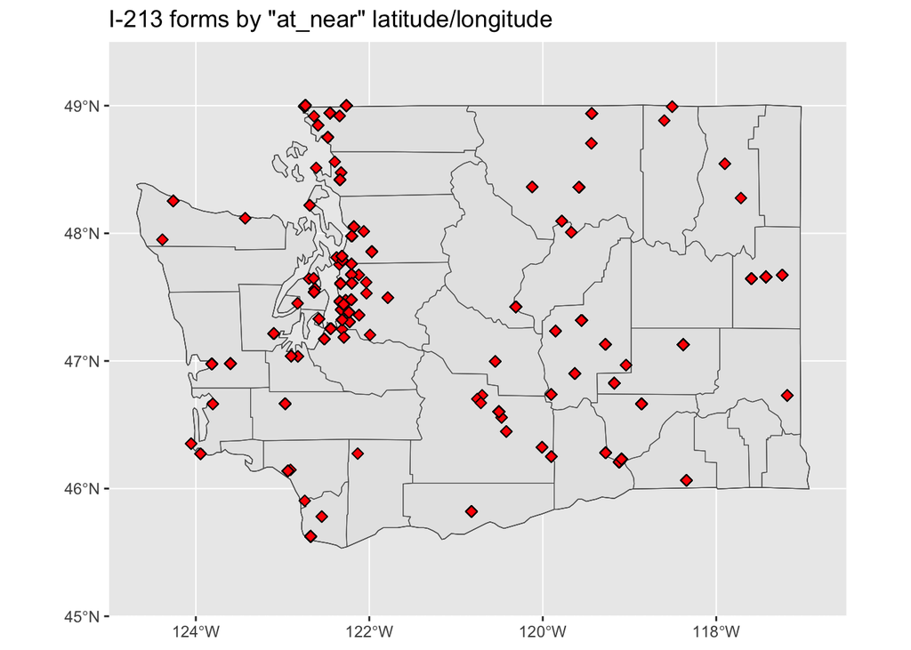

```r
world <- ne_countries(scale = "medium", returnclass = "sf")

states <- st_as_sf(map("state", crs = 4326, plot = FALSE, fill = TRUE))

states <- cbind(states, st_coordinates(st_point_on_surface(states)))
states$ID <- toTitleCase(as.character(states$ID))

wa <- states %>%
  filter(ID == 'Washington')

counties <- st_as_sf(map("county", plot = FALSE, fill = TRUE))

counties <- counties %>%
  separate(col = 'ID', into = c("state", "county"), sep = ",", remove = FALSE) %>%
  filter(state == 'washington')

counties$area <- as.numeric(st_area(counties))

sites <- i213 %>% select(lon, lat) %>%
  na.omit()

sites <- st_as_sf(sites, coords = c("lon", "lat"),
                   crs = 4326, agr = "constant")

wa_coords <- coord_sf(xlim = c(-125, -116.5), ylim = c(45, 49.5), expand = FALSE, crs = 4326)

st_crs(wa) <- 4326
st_crs(wa$geom) <- 4326
st_crs(sites) <- 4326
st_crs(sites$geometry) <- 4326

ggplot(data = wa) +
    geom_sf() +
    geom_sf(data = wa, fill = NA) +
    geom_sf(data = counties, fill = NA) +
    geom_sf(data = sites, size = 2, shape = 23, fill = "red") +
    wa_coords +
    ggtitle('I-213 forms by "at_near" latitude/longitude')
```

Note distribution of arrests throughout the state, with larger clusters along the northern border in Whatcom County and in SeaTac, locaiton of both the Seattle-Tacoma International Airport and SeaTac Federal Detention Center.

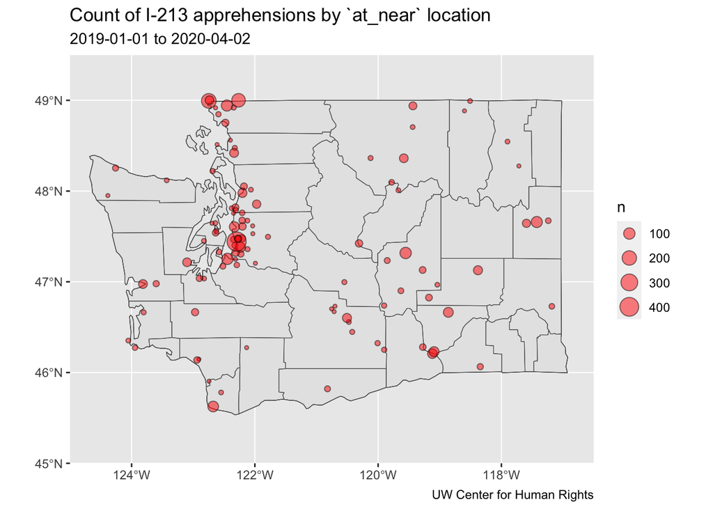

```r
data_at_near <- i213 %>%
  filter(year >= '2019') %>%
  group_by(at_near, lon, lat) %>%
  summarise(n = n()) %>%
  na.omit()

data_at_near <- st_as_sf(data_at_near, coords = c("lon", "lat"),
                  crs = 4326, agr = "constant")

data_at_near$rank <- rank(data_at_near$n)

p1 <- ggplot(data = wa) +
    geom_sf() +
    geom_sf(data = wa, fill = NA) +
    geom_sf(data = counties, fill = NA) +
    geom_sf(data = data_at_near, aes(size=n), shape = 21, fill = "red", alpha=.5) +
    wa_coords +
    labs(x = NULL, y = NULL,
    title = "Count of I-213 apprehensions by `at_near` location",
    subtitle = paste(min_date, max_date, sep = ' to '),
    caption = "UW Center for Human Rights")

p1
```

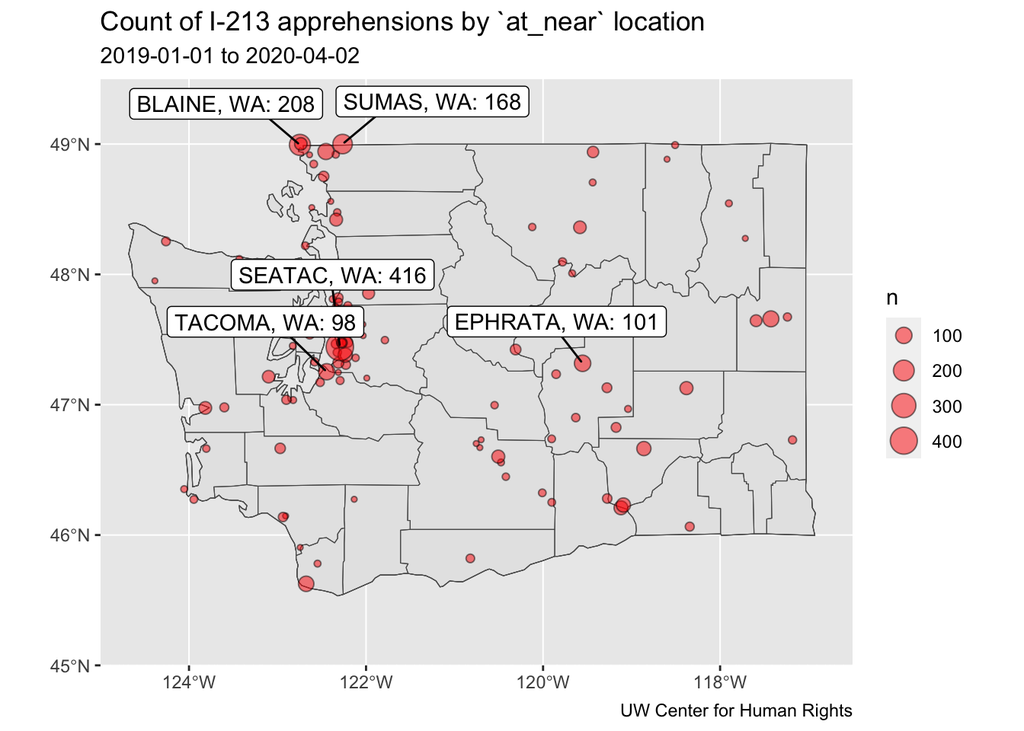

```r
ggsave('wa-i213-count.png',
       plot = p1,
       device = 'png',
       path = '../output',
       scale = 1,
       dpi = 300)

p2 <- ggplot(data = wa) +
    geom_sf() +
    geom_sf(data = wa, fill = NA) +
    geom_sf(data = counties, fill = NA) +
    geom_sf(data = data_at_near, aes(size=n), shape = 21, fill = "red", alpha=.5) +
    ggsflabel::geom_sf_label_repel(data = subset(data_at_near, rank > (nrow(data_at_near) - 5)),
                        aes(label = paste(at_near, n, sep=': '),
                            background = NA),
                        force = 50,
                        nudge_x = -.33,
                        nudge_y = .33) +
    wa_coords +
    labs(x = NULL, y = NULL,
    title = "Count of I-213 apprehensions by `at_near` location",
    subtitle = paste(min_date, max_date, sep = ' to '),
    caption = "UW Center for Human Rights")

p2
```

```r
ggsave('wa-i213-count-labeled.png',
       plot = p2,
       device = 'png',
       path = '../output',
       scale = 1,
       dpi = 300)
```

Here we sum total arrests by county, and also generate a simple diagram of priority counties selected for UWCHR’s “Immigrant Rights Observatory” project.

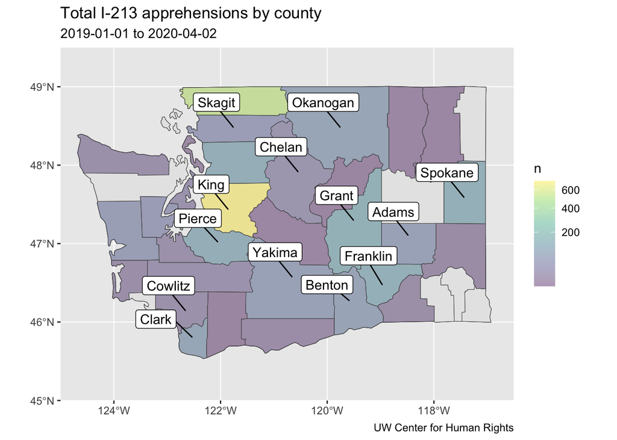

```r
data <- i213 %>%
  group_by(county, state) %>%
  summarise(n = n()) %>%
  na.omit()

data$state <- data$state %>%
  str_replace_all(c("WA" = "washington", "OR" = "oregon", 'ID' = 'idaho', 'AK' = 'alaska'))

data$county <- data$county %>%
  str_replace_all(c(" County" = "")) %>%
  tolower()

data$ID <- paste(data$state, data$county, sep=',')

counties <- left_join(counties, data, by=c("ID", "state", 'county'))

study_counties <- counties %>%
  filter(county %in% priority_counties)

m1 <- ggplot(data = wa) +
    geom_sf() +
    geom_sf(data = wa, fill = NA) +
    geom_sf(data = counties, aes(fill = n)) +
    ggsflabel::geom_sf_label_repel(data = study_counties, aes(label = str_to_title(county)),
                        nudge_x = -.33,
                        nudge_y = .33,
                        force = 75) +
    scale_fill_viridis_c(trans = "sqrt", alpha = .4, na.value = gray(.9)) +
    wa_coords +
    labs(x = NULL, y = NULL,
       title = "Total I-213 apprehensions by county",
       subtitle = paste(min_date, max_date, sep = ' to '),
       caption = "UW Center for Human Rights")

m1
```

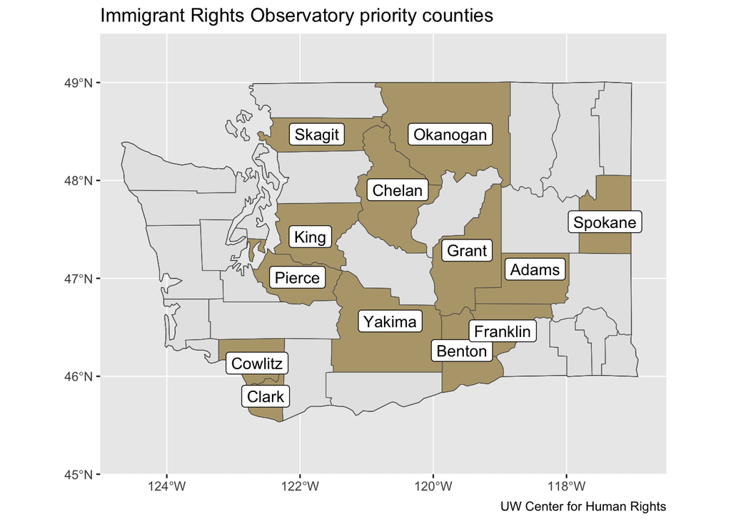

```r
ggsave('wa-i213-county-total.png',
       plot = m1,
       device = 'png',
       path = '../output',
       scale = 1,
       dpi = 300)

m2 <- ggplot(data = wa) +
    geom_sf() +
    geom_sf(data = wa, fill = NA) +
    geom_sf(data = counties, fill = NA) +
    geom_sf(data = study_counties, aes(fill = 'priority')) +
    geom_sf_label_repel(data = study_counties, aes(label = str_to_title(county), background = NA), force = 0) +
    wa_coords +
    labs(x = NULL, y = NULL, fill = NULL,
       title = "Immigrant Rights Observatory priority counties",
       caption = "UW Center for Human Rights") +
    annotate("text", x = 4, y = 25, label = "Some text") +
    theme(legend.position = "none") + scale_fill_manual(values=c("#b7a57a"))

m2
```

```r
ggsave('wa-priority-counties.png',
       plot = m2,
       device = 'png',
       path = '../output',
       scale = 1,
       dpi = 300)
```

Here we calculate and map rate of I-213 apprehensions per capita, using ACS 5 year 2014-2018 population estimates.

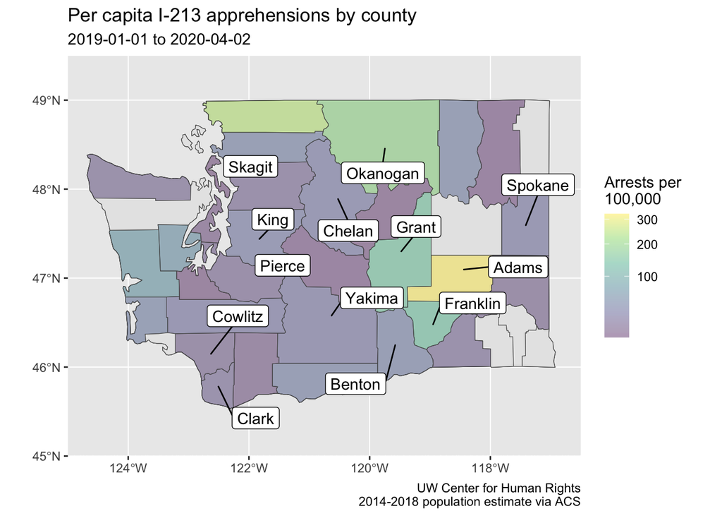

```r
wa_pop <- read.delim(here::here('map', 'input', 'wa-pop.csv'), sep=',')

wa_total_pop <- wa_pop %>%
  filter(name == "washington")

wa_total_pop <- wa_total_pop$estimate

wa_pop <- wa_pop %>%
  filter(name != "washington")

wa_pop$name <- gsub(" county", "", wa_pop$name)
wa_pop$name <- str_trim(wa_pop$name)

wa_pop <- wa_pop %>%
  separate(., col=name, sep=',',
           remove = FALSE,
           into=c('county', 'state'))

wa_pop$state <- str_trim(wa_pop$state)
wa_pop$county <- str_trim(wa_pop$county)

wa_pop <- wa_pop %>%
  mutate(priority = county %in% priority_counties)

wa_pop <- wa_pop %>%
  mutate(priority_plus = county %in% priority_plus)

wa_pop_prior <- wa_pop %>%
  filter(priority == TRUE)

wa_pop_prior_plus <- wa_pop %>%
  filter(priority_plus == TRUE)

wa_pop_prior <- sum(wa_pop_prior$estimate)
wa_pop_prior_plus <- sum(wa_pop_prior_plus$estimate)

prop_pop_prior <- wa_pop_prior / wa_total_pop
wa_pop_prior_plus <- wa_pop_prior_plus / wa_total_pop

# merge and calcuiate n forms per capita

data <- merge(counties, wa_pop, by=c('county', 'state'))

data$i_213_per_capita <- data$n / data$estimate * 100000

# Checking # of forms in priority counties
forms_wa <- data %>%
  filter(state == 'washington')

forms_prior <- data %>%
  filter(priority == TRUE)

forms_prior_plus <- data %>%
  filter(priority_plus == TRUE)

wa_forms_prior <- sum(forms_prior$n) / sum(forms_wa$n)

wa_forms_prior_plus <- sum(forms_prior_plus$n) / sum(forms_wa$n)

total_forms_prior <- sum(forms_prior$n) / sum(data$n)

m1 <- ggplot(data = wa) +
    geom_sf() +
    geom_sf(data = wa, fill = NA) +
    geom_sf(data = data, aes(fill = i_213_per_capita)) +
    wa_coords +
    ggsflabel::geom_sf_label_repel(data = study_counties, aes(label = str_to_title(county), background = NA), force = 100) +
    labs(x = NULL, y = NULL,
       title = "Per capita I-213 apprehensions by county",
       subtitle = paste(min_date, max_date, sep = ' to '),
       caption = "UW Center for Human Rights\n2014-2018 population estimate via ACS") +
  guides(fill=guide_colorbar(title="Arrests per\n100,000")) +
    scale_fill_viridis_c(trans = "sqrt", alpha = .4, na.value = gray(.9))

m1
```

```r
ggsave('wa-i213-county-per-capita.png',
       plot = m1,
       device = 'png',
       path = '../output',
       scale = 1,
       dpi = 300)
```

Table of apprehensions per capita:

```r
to_print <- data %>%
  select(c('county', 'n', 'estimate', 'i_213_per_capita')) %>%
  mutate(county = str_to_title(county))

st_geometry(to_print) <- NULL

total_arrests <- sum(to_print$n, na.rm=TRUE)
wa_per_capita <- total_arrests / wa_total_pop * 100000

to_print <- to_print %>%
  add_row(county = 'Washington state total',
          estimate = wa_total_pop,
          n = total_arrests,
          i_213_per_capita = wa_per_capita)

to_print <- to_print %>%
  arrange(desc(i_213_per_capita))

col_names <- c('County', 'Total apprehensions', 'Population','Apprehensions per capita')

caption <- paste("WA State I-213 apprehensions per capita\n", min_date, " to ", max_date, sep='')
caption_html <- paste("<b>WA State I-213 apprehensions per capita</b><br><i>", min_date, " to ", max_date, sep='')

write(knitr::kable(to_print, caption = caption_html, col.names = col_names, digits=4, 'html'), '../output/i213-per-capita.html')
print(knitr::kable(to_print, caption = caption, col.names = col_names, digits=4))
```

```
##
##
## Table: WA State I-213 apprehensions per capita
## 2019-01-01 to 2020-04-02
##
## |County                 | Total apprehensions| Population| Apprehensions per capita|
## |:----------------------|-------------------:|----------:|------------------------:|
## |Adams                  |                  63|      19452|                 323.8742|
## |Whatcom                |                 540|     216812|                 249.0637|
## |Okanogan               |                  82|      41638|                 196.9355|
## |Grant                  |                 137|      94860|                 144.4234|
## |Franklin               |                 128|      90660|                 141.1869|
## |Grays Harbor           |                  53|      71967|                  73.6449|
## |Mason                  |                  41|      62627|                  65.4670|
## |Pacific                |                   9|      21281|                  42.2912|
## |Skagit                 |                  50|     123907|                  40.3528|
## |Ferry                  |                   3|       7576|                  39.5987|
## |Klickitat              |                   8|      21396|                  37.3902|
## |Benton                 |                  72|     194168|                  37.0813|
## |Washington state total |                2543|    7294336|                  34.8627|
## |King                   |                 708|    2163257|                  32.7284|
## |Chelan                 |                  22|      75757|                  29.0402|
## |Spokane                |                 132|     497875|                  26.5127|
## |Lewis                  |                  20|      76947|                  25.9919|
## |Yakima                 |                  63|     249325|                  25.2682|
## |Clark                  |                  85|     465384|                  18.2645|
## |Walla Walla            |                  10|      60236|                  16.6014|
## |Clallam                |                  12|      74487|                  16.1102|
## |Snohomish              |                 122|     786620|                  15.5094|
## |Pierce                 |                 117|     859840|                  13.6072|
## |Cowlitz                |                  14|     105112|                  13.3191|
## |Whitman                |                   6|      48593|                  12.3475|
## |Skamania               |                   1|      11620|                   8.6059|
## |Kitsap                 |                  20|     262475|                   7.6198|
## |Stevens                |                   3|      44214|                   6.7852|
## |Kittitas               |                   3|      44825|                   6.6927|
## |Island                 |                   4|      81636|                   4.8998|
## |Douglas                |                   2|      41371|                   4.8343|
## |Thurston               |                  13|     274684|                   4.7327|
## |Asotin                 |                  NA|      22337|                       NA|
## |Columbia               |                  NA|       4001|                       NA|
## |Garfield               |                  NA|       2224|                       NA|
## |Jefferson              |                  NA|      30856|                       NA|
## |Lincoln                |                  NA|      10435|                       NA|
## |Pend Oreille           |                  NA|      13219|                       NA|
## |San Juan               |                  NA|      16473|                       NA|
## |Wahkiakum              |                  NA|       4189|                       NA|
```